# 地域メッシュ統計による人口密度の可視化

静岡県の例

[岩田真一郎](https://shinichiro-iwata.github.io/)（ [神奈川大学経済学部](https://www.econ.kanagawa-u.ac.jp/)）

2022-06-02作成，2025-01-12改定

# 1 目的

[国土数値情報ダウンロードサービス](https://nlftp.mlit.go.jp/ksj/)の行政区域（ポリゴン）に人口密度（地域メッシュ統計）を重ねる．

パッケージ：`sf`，`tidyverse`

```r
library(sf)
library(tidyverse)
```

# 2 人口密度の可視化

人口密度を示す方法はいくつかある．ここでは，その方法の一つとして，静岡県の行政区域（ポリゴン）に1kmメッシュ別人口を重ねる方法を紹介する．

データとしては500mメッシュも用意されているが，都道府県など範囲が広い場合は，メッシュが相対的に小さく，見えにくくなる．

**シェープファイルのダウンロード**

- [国土数値情報ダウンロードサービス](https://nlftp.mlit.go.jp/ksj/) > 行政区域（ポリゴン） > 静岡県 > 令和3年
- [国土数値情報ダウンロードサービス](https://nlftp.mlit.go.jp/ksj/) > 1kmメッシュ別将来推計人口（H30国政局推計）（shape形式版） > 静岡県 > 世界測地系
  - ダウンロードしたZIPファイルは同じフォルダ（ディレクトリ）に納め，ZIPファイルを選択 > 右クリック > すべて展開 > 展開先の選択とファイルの選択 > 展開を実行する．展開後は最初にダウンロードしたZIPファイルを削除
  - シェープファイルの読み込み（`read_sf`），`Shizuoka_map`と名付ける．
  - 必要に応じて各種ファイルを読み込む際にオプション（`encoding="cp932"`，`fileEncoding="CP932"`など）で日本語の文字化けを防ぐ．
  - 文字化けが解消できない場合は[Rのエンコーディング問題](https://shohei-doi.github.io/quant_polisci/encoding-r.html)を参照．

**行政区域の可視化**

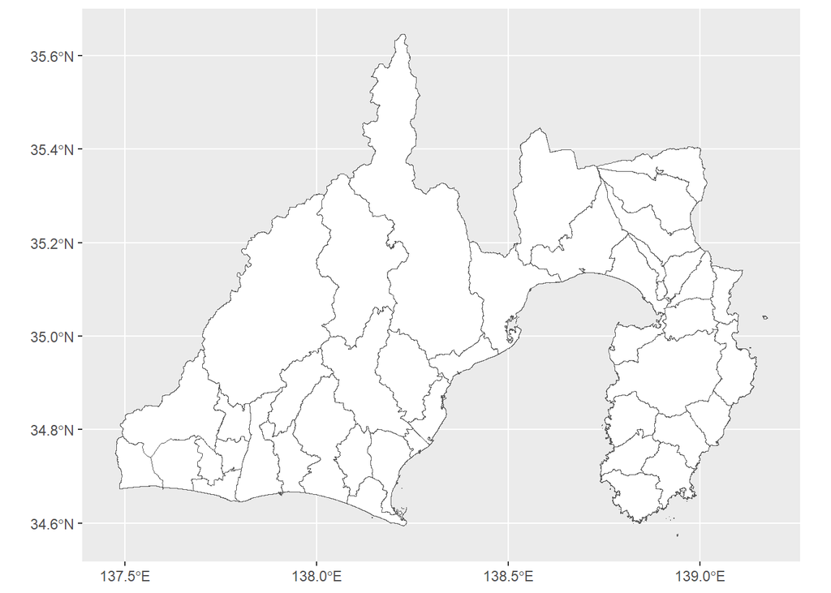

```r
Shizuoka_map <-
  read_sf("N03-20210101_22_GML/N03-21_22_210101.shp")

#行政区域の可視化
ggplot()+
  geom_sf(data=Shizuoka_map, fill="white")
```

**参考**

- 次の図の作成方法は出力していないが，[Rを使ってシェープファイルから白地図を描く](https://qiita.com/nozma/items/8e890595c07d3be86bc9)（アクセス日：2022-05-19）のコードを参考に作成．

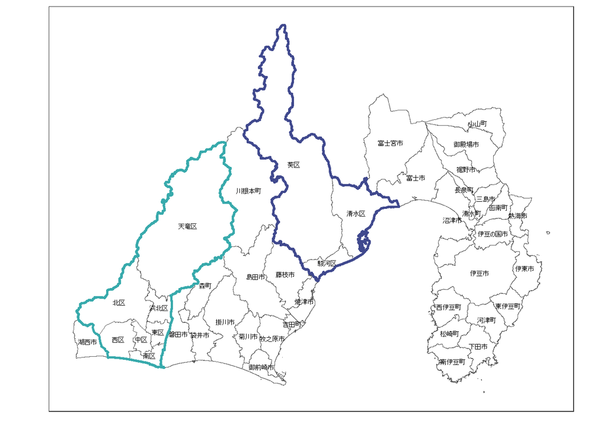

**1kmメッシュ別人口の可視化**

1kmメッシュ別将来推計人口（H30国政局推計）のファイルには2015年の人口とそれ以降の将来推計人口がメッシュ毎に計算されている．ここでは2015年の人口（`PTN_2015`）を利用．

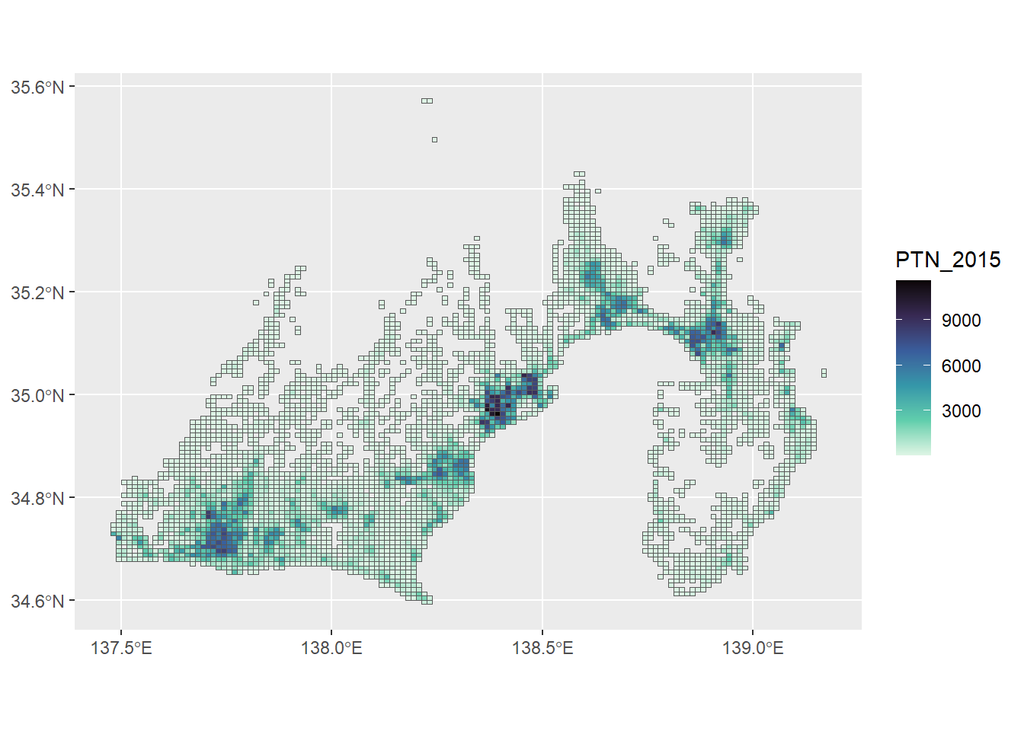

```r
Shizuoka_mesh <-
  read_sf("1km_mesh_suikei_2018_shape_22/1km_mesh_2018_22.shp")

#1kmメッシュ別人口の可視化
ggplot()+
  geom_sf(data=Shizuoka_mesh,
          aes(fill=PTN_2015))+
  scale_fill_viridis_c(option="G", direction=-1)
```

# 3 完成図

2枚の地図を重ねる．図のタイトル，凡例をつけて，完成図を示す． - `color="NA"`によりメッシュの枠線を透明に． - `labs()`の凡例（`aes`の`fill`）を「人」にするように指示． - `labs()`に出典表記（`caption`）． - `ggplot()`はデフォルトのままの場合，背面は灰色，線は白で描写（`theme_grey()`）.`theme_bw()`（black & white）を利用すること背面を白，線を黒に変更可能．

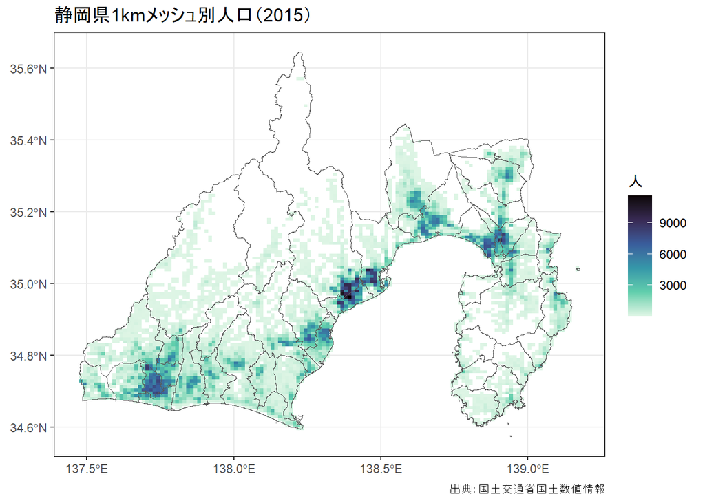

```r
ggplot()+
  geom_sf(data=Shizuoka_map, fill="white")+
  geom_sf(data=Shizuoka_mesh, aes(fill=PTN_2015),
          color="NA")+
  scale_fill_viridis_c(option="G", direction=-1)+
  geom_sf(data=Shizuoka_map, fill="NA")+
  labs(fill="人",
       caption="出典：国土交通省国土数値情報")+
  ggtitle("静岡県1kmメッシュ別人口（2015）")+
  theme_bw()
```

# 4 応用例

## 4.1 予想人口変化率の可視化

1kmメッシュ別将来推計人口（H30国政局推計）には将来の人口予想の推計も記されている．そこで，予想人口変化率を計算し，可視化．

- 2015年ー2035年（20年後）の予想人口変化率を計算する．
  - 2035年の予想人口は`PTN_2035`．
  - 変化率（ここでは`Pop_rate`と表現する）は`(PTN_2035-PTN_2015)/PTN_2015)*100`．
  - `mutate()`：列名の変更や列の追加を可能にする．データが格納されているオブジェクト`Shizuoka_mesh`に列名の変更や列の追加を指示．

```r
Shizuoka_mesh %>%
  mutate(Pop_rate=((PTN_2035-PTN_2015)/PTN_2015)*100) ->
  Shizuoka_mesh
```

- `scale_fill_gradient2()`は枠内の中間値（初期値は`0`）より大きな値と小さな値で色を塗り分けることを可能にする関数．
  - ここでは，変化率0を白，負を青，正を赤に設定．

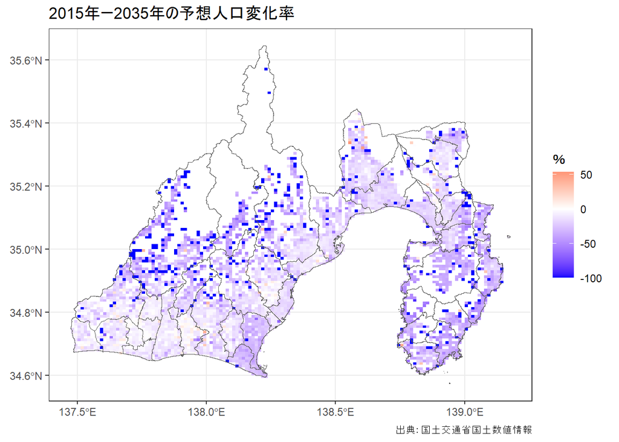

```r
ggplot()+
  geom_sf(data=Shizuoka_map, fill="white")+
  geom_sf(data=Shizuoka_mesh, aes(fill=Pop_rate),
          color="NA")+
  scale_fill_gradient2(low="blue",
                       mid="white",
                       high="red")+
  geom_sf(data=Shizuoka_map, fill="NA")+
  labs(fill="％", color="％",
       caption="出典：国土交通省国土数値情報")+
  ggtitle("2015年ー2035年の予想人口変化率")+
  theme_bw()
```

**Rによる地理空間データの可視化**

- チュートリアル[ホーム](https://shinichiro-iwata.github.io/geospatial-data-visualization/)